# Available Optimizers: How to Find Maximum A Posteriori?

```r
library(gips)
```

```r
?find_MAP()
```

# What are we optimizing?

The goal of the `find_MAP()` is to find the permutation $\sigma$ that maximizes the a posteriori probability (MAP - Maximum A Posteriori). Such a permutation represents the most plausible symmetry given the data.

This a posteriori probability function is described in-depth in the **Bayesian model selection** section of the `vignette("Theory", package="gips")`, also available as a [pkgdown page](https://przechoj.github.io/gips/articles/Theory.html). `gips` can calculate the logarithm of it by the `log_posteriori_of_gips()` function. In the following paragraphs, we will refer to this a posteriori probability function as $f(\sigma)$. We have $f(\sigma) > 0$.

# Available optimizers

The space of permutations is enormous - for the permutation of size $p$, the space of all permutations is of size $p!$ ($p$ factorial). Even for $p=12$, this space is practically impossible to browse. This is why `find_MAP()` implements multiple (3) optimizers to choose from:

- `"brute_force"`, `"BF"`, `"full"` | recommended for $p\le 10$.
- `"Metropolis_Hastings"`, `"MH"` | recommended for $p\ge 11$.
- `"hill_climbing"`, `"HC"`

### Note on computation time

The `max_iter` parameter works differently in Metropolis-Hastings and hill climbing.

For Metropolis-Hastings, it computes the a posteriori probability for `max_iter` permutations, whereas for hill climbing, it computes ${p\choose 2} \cdot$ `max_iter` of them.

In the case of the Brute Force optimizer, it computes all $f(\sigma)$ values. The number of all different $\sigma$ follows [OEIS sequence A051625](https://oeis.org/A051625).

## Brute Force

It searches through the whole space at once.

This is the only optimizer that will certainly find the true MAP estimator.

Brute Force is **only recommended** for small spaces ($p \le 10$). It can also browse bigger spaces, but the required time is probably too long.

The table below reports one measurement per dimension on an Apple M2, using `n_reps = 1` and `n_cores = 1`. Runs were executed sequentially, each preceded by a BF warmup at $p = 6$. The recorded optimizer times exclude data generation and the warmup and are rounded for display.

```r
library(gips)
# install.packages("pbmcapply")
library(pbmcapply)

get_gips_for_p <- function(p, n = 30) {
  S_inv <- diag(1, p, p)
  S_inv[1, 2:p] <- -1/sqrt(p)
  S_inv[2:p, 1] <- -1/sqrt(p)

  Sigma <- chol2inv(chol(S_inv))
  Z <- matrix(rnorm(n * p), nrow = n) %*% chol(Sigma)
  S <- cov(Z)
  S <- (S + t(S)) / 2 # Ensure exact symmetry for gips().

  gips(S, n)
}

get_time <- function(p, optimizer, max_iter = NA, seed = 1234) {
  set.seed(seed)
  g <- get_gips_for_p(p)
  g_MAP <- suppressWarnings(
    find_MAP(g, optimizer = optimizer, max_iter = max_iter, show_progress_bar = FALSE)
  )

  as.numeric(attr(g_MAP, "optimization_info")$optimization_time, units = "secs")
}

benchmark_optimization <- function(
    n_reps = 1, n_cores = 1, seed = 1234) {
  make_label <- function(optimizer, p, max_iter = NA) {
    if (is.na(max_iter)) {
      paste0(optimizer, " p=", p)
    } else {
      paste0(optimizer, " p=", p, ", ", max_iter)
    }
  }

  cases <- data.frame(
    p = c(2, 3, 4, 5, 6, 7, 8, 9, 10),
    max_iter = c(NA, NA, NA, NA, NA, NA, NA, NA, NA),
    stringsAsFactors = FALSE
  )

  cases$optimizer <- ifelse(is.na(cases$max_iter), "BF", "MH")

  cases$label <- mapply(
    make_label,
    optimizer = cases$optimizer,
    p = cases$p,
    max_iter = cases$max_iter
  )
  label_levels <- unique(cases$label)

  jobs <- cases[rep(seq_len(nrow(cases)), each = n_reps), ]
  jobs$rep <- rep(seq_len(n_reps), times = nrow(cases))
  jobs$seed <- seed + seq_len(nrow(jobs))

  rownames(jobs) <- NULL

  run_one_job <- function(j) {
    job <- jobs[j, ]

    # Warm up each worker on a small problem, outside the recorded timings.
    invisible(get_time(
      p = 6L,
      optimizer = job$optimizer,
      max_iter = if (is.na(job$max_iter)) NA else min(job$max_iter, 5L),
      seed = 1L
    ))

    # get_time() resets the seed before generating the measured sample.

    data.frame(
      label = job$label,
      p = job$p,
      optimizer = job$optimizer,
      max_iter = job$max_iter,
      rep = job$rep,
      seed = job$seed,
      time = get_time(
        p = job$p,
        optimizer = job$optimizer,
        max_iter = job$max_iter,
        seed = job$seed
      ),
      stringsAsFactors = FALSE
    )
  }

  results_list <- pbmcapply::pbmclapply(
    X = seq_len(nrow(jobs)),
    FUN = run_one_job,
    mc.cores = n_cores
  )

  results <- do.call(rbind, results_list)

  results$label <- factor(results$label, levels = label_levels)
  rownames(results) <- NULL

  results
}

start_time <- Sys.time()
# For 1.4.0, consider increasing n_reps while keeping runs sequential.
benchmark_results <- benchmark_optimization(n_reps = 1, n_cores = 1, seed = 1234)
end_time <- Sys.time()
end_time - start_time

aggregate(
  time ~ label,
  data = benchmark_results,
  FUN = function(x) {
    c(
      median = median(x),
      mean = mean(x),
      min = min(x),
      max = max(x),
      sd = sd(x)
    )
  }
)
```

| p=2 | p=3 | p=4 | p=5 | p=6 | p=7 | p=8 | p=9 | p=10 |
| --- | --- | --- | --- | --- | --- | --- | --- | --- |
| 0.000676 sec | 0.00138 sec | 0.00394 sec | 0.0156 sec | 0.0887 sec | 0.522 sec | 3.86 sec | 31 sec | 5 min |

### Example

```r
perm_size <- 6
mu <- runif(perm_size, -10, 10) # Assume we don't know the mean
sigma_matrix <- matrix(
  data = c(
    1.0, 0.8, 0.6, 0.4, 0.6, 0.8,
    0.8, 1.0, 0.8, 0.6, 0.4, 0.6,
    0.6, 0.8, 1.0, 0.8, 0.6, 0.4,
    0.4, 0.6, 0.8, 1.0, 0.8, 0.6,
    0.6, 0.4, 0.6, 0.8, 1.0, 0.8,
    0.8, 0.6, 0.4, 0.6, 0.8, 1.0
  ),
  nrow = perm_size, byrow = TRUE
) # the real covariance matrix, that we want to estimate, is invariant under permutation (1,2,3,4,5,6)
number_of_observations <- 13
Z <- withr::with_seed(2022,
  code = MASS::mvrnorm(number_of_observations, mu = mu, Sigma = sigma_matrix)
)
```

Let’s say we have the data `Z` from the unknown process:

```r
dim(Z)
```

```
#> [1] 13  6
```

```r
number_of_observations <- nrow(Z) # 13
perm_size <- ncol(Z) # 6
S <- cov(Z) # Assume we have to estimate the mean

g <- gips(S, number_of_observations)

g_map <- find_MAP(g, optimizer = "brute_force")
g_map
```

```
#> The permutation (1,2,3,4,5,6):
#>  - was found in a search using 362 posterior calculations;
#>  - is 28979.967 times more likely than the () permutation.
```

Brute Force needed 362 calculations, as predicted in [OEIS sequence A051625](https://oeis.org/A051625) for $p = 6$.

## Metropolis-Hastings

This optimizer is based on the *Second approach* from [[1, Sec 4.1.2]](https://arxiv.org/abs/2004.03503).

It uses the Metropolis-Hastings algorithm to optimize the space; [see Wikipedia](https://en.wikipedia.org/wiki/Metropolis%E2%80%93Hastings_algorithm). This algorithm used in this context is a special case of the Simulated Annealing the reader may be more familiar with; [see Wikipedia](https://en.wikipedia.org/wiki/Simulated_annealing).

The `MH` optimizer supplements ordinary Metropolis steps with forced moves and temporary restrictions on reversing them to help escape local optima. It searches for MAP; visit frequencies should not be interpreted as posterior probabilities. See [issue #115](https://github.com/PrzeChoj/gips/issues/115) for details.

### Short description

In an ordinary Metropolis step, the algorithm considers a permutation, say, $\sigma_i$. Then a random transposition is drawn uniformly $t_i = (j,k)$, and the value of $f(\sigma_i \circ t_i)$ is computed.

- If a new value is bigger than the previous one (i.e., $f(\sigma_i \circ t_i) \ge f(\sigma_i)$), then we set $\sigma_{i+1} = \sigma_i \circ t_i$.
- If a new value is smaller ($f(\sigma_i \circ t_i) < f(\sigma_i)$), then we will choose $\sigma_{i+1} = \sigma_i \circ t_i$ with probability $\frac{f(\sigma_i \circ t_i)}{f(\sigma_i)}$. Otherwise, we set $\sigma_{i+1} = \sigma_i$ with complementary probability $1 - \frac{f(\sigma_i \circ t_i)}{f(\sigma_i)}$.

The final value is the best $\sigma$ ever computed.

### Notes

This algorithm was tested in multiple settings and turned out to be a good optimizer for this problem. Especially given it does not need any hyperparameters tuned.

The only parameter it depends on is `max_iter`, which determines the number of steps described above. One should choose this number rationally. When set too small, there is a missed opportunity to find a much better permutation. When set too big, there is a lost time and computational power that does not lead to growth. We recommend plotting the convergence plot with a logarithmic OX scale: `plot(g_map, type = "best", logarithmic_x = TRUE)`, then decide if the line has flattened already. Keep in mind that the OY scale is also logarithmic. For example, a marginal change on the OY scale could mean $10000$ **times** the change in A Posteriori.

For more information about continuing the optimization, see the **Continuing the optimization** section below.

### Example

```r
perm_size <- 70
number_of_observations <- 50
Z <- withr::with_seed(2022, {
  mu <- runif(perm_size, -10, 10) # Assume we don't know the mean
  sigma_matrix <- crossprod(matrix(rnorm(perm_size * perm_size), nrow = perm_size))
  # sigma_matrix is the real covariance matrix, that we want to estimate based on Z
  MASS::mvrnorm(number_of_observations, mu = mu, Sigma = sigma_matrix)
})
```

Let’s say we have the data `Z` from the unknown process:

```r
dim(Z)
```

```
#> [1] 50 70
```

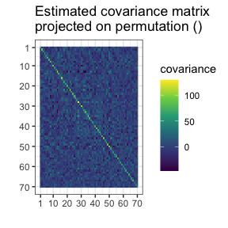

```r
number_of_observations <- nrow(Z) # 50
perm_size <- ncol(Z) # 70
S <- cov(Z) # Assume we have to estimate the mean

g <- gips(S, number_of_observations)
suppressMessages( # message from ggplot2
  plot(g, type = "heatmap") +
    ggplot2::scale_x_continuous(breaks = c(1, 10, 20, 30, 40, 50, 60, 70)) +
    ggplot2::scale_y_reverse(breaks = c(1, 10, 20, 30, 40, 50, 60, 70))
)
```

```r
g_map <- withr::with_seed(2023,
  code = find_MAP(g, max_iter = 150, optimizer = "Metropolis_Hastings")
)
g_map
```

```
#> The permutation (1,30,6,8,21,64,24,61,7,62,31,25,52,14,35,33,40,51,68,4,11,50,42,16,34,54,27,60,46,20,45,38,2,65,55,59,15,67,5,12,63,22,28,70,23)(3,37,66,18,56,36,57,29,58,9,17,10,41,43,53,69,39,48,47,44,19,32,26):
#>  - was found in a search using 150 posterior calculations;
#>  - is 5.915e+657 times more likely than the () permutation.
```

After 150 iterations, the best group found is unimaginably more likely than the trivial group generated by the identity permutation `()`: its posterior probability is approximately $10^{658}$ times as large.

[figure not shown]

```r
plot(g_map, type = "best", logarithmic_x = TRUE)
```

## Hill climbing

It uses the Hill climbing algorithm to optimize the space; [see Wikipedia](https://en.wikipedia.org/wiki/Hill_climbing).

It is performing the local optimization iteratively.

### Short description

In every iteration $i$, an algorithm considers a permutation; call it $\sigma_i$. Then, all the values of $f(\sigma_i \circ t)$ are computed for every possible transposition $t = (j,k)$. Then the next $\sigma_{i+1}$ will be the one with the biggest value:

$$\sigma_{i+1} =
\operatorname*{arg\,max}_{\text{perm} \in
\text{neighbors}(\sigma_{i})}\{f(\text{perm})\}$$

Where:
$$\text{neighbors}(\sigma) =
\{\sigma \circ (j,k) : 1 \le j < k \le \text{p}\}$$

The algorithm ends when all neighbors are less likely, or the `max_iter` is achieved. In the first case, the algorithm will finish at a local maximum, but there is no guarantee that this is also the global maximum.

### Pseudocode

```r
hill_climb <- function(g, max_iter) {
  perm <- g[[1]]
  perm_log_f <- log_posteriori_of_gips(g)
  perm_size <- attr(perm, "size")
  S <- attr(g, "S")
  number_of_observations <- attr(g, "number_of_observations")

  best_neighbor <- NULL
  best_neighbor_log_f <- -Inf

  i <- 1
  perm_i <- perm
  perm_i_log_f <- perm_log_f
  perm_i_minus_1_log_f <- -Inf

  while (i < max_iter) {
    best_neighbor <- NULL
    best_neighbor_log_f <- -Inf

    for (j in 1:(perm_size - 1)) {
      for (k in (j + 1):perm_size) {
        t <- c(j, k)
        neighbor <- gips:::compose_with_transposition(perm_i, t)
        neighbor_log_f <- log_posteriori_of_gips(gips(
          S, number_of_observations,
          perm = neighbor
        ))

        if (neighbor_log_f > best_neighbor_log_f) {
          best_neighbor <- neighbor
          best_neighbor_log_f <- neighbor_log_f
        } # end if
      } # end for k
    } # end for j
    i <- i + 1

    perm_i_minus_1_log_f <- perm_i_log_f

    if (best_neighbor_log_f <= perm_i_log_f) {
      break
    }

    perm_i <- best_neighbor
    perm_i_log_f <- best_neighbor_log_f
  } # end while

  return(perm_i)
}
```

### Example

```r
perm_size <- 25
number_of_observations <- 20
Z <- withr::with_seed(2022, {
  mu <- runif(perm_size, -10, 10) # Assume we don't know the mean
  sigma_matrix <- crossprod(matrix(rnorm(perm_size * perm_size), nrow = perm_size))
  # sigma_matrix is the real covariance matrix, that we want to estimate based on Z
  MASS::mvrnorm(number_of_observations, mu = mu, Sigma = sigma_matrix)
})
```

Let’s say we have the data `Z` from the unknown process:

```r
dim(Z)
```

```
#> [1] 20 25
```

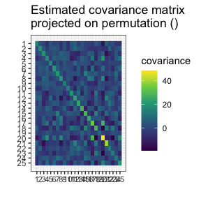

```r
number_of_observations <- nrow(Z) # 20
perm_size <- ncol(Z) # 25
S <- cov(Z) # Assume we have to estimate the mean

g <- gips(S, number_of_observations)
plot(g, type = "heatmap")
```

```r
# we will see a warning:
g_map <- find_MAP(g, max_iter = 2, optimizer = "hill_climbing")
```

```
#> ================================================================================
#> Warning: Hill Climbing algorithm did not converge in 2 iterations!
#> ℹ We recommend to run the `find_MAP(optimizer = 'continue')` on the acquired output.
#> Warning: The found permutation has n0 = 24, which is bigger than the number_of_observations = 20.
#> ℹ The covariance MLE is unavailable because the sample-size requirement is not met.
#> ℹ For a more in-depth explanation, see the 'Project Matrix - Equation (6)' section in the `vignette('Theory', package = 'gips')` or its pkgdown page: https://przechoj.github.io/gips/articles/Theory.html.
```

```r
g_map
```

```
#> The permutation (1,13)(5,21):
#>  - was found in a search using 601 posterior calculations;
#>  - is 2.234e+21 times more likely than the () permutation.
```

[figure not shown]

```r
plot(g_map, type = "best")
```

# Continuing the optimization

When `max_iter` is reached during Metropolis-Hastings or hill climbing, the optimization stops and returns the result. Plot the best result found so far to assess whether it is still improving. A flat segment does not guarantee that the global maximum has been reached. Users can continue the optimization, as shown below.

```r
# Generate data as in the Metropolis-Hastings example above,
# with a fixed seed for all random draws.

perm_size <- 70
number_of_observations <- 50
Z <- withr::with_seed(2022, {
  mu <- runif(perm_size, -10, 10) # Assume we don't know the mean
  sigma_matrix <- crossprod(matrix(rnorm(perm_size * perm_size), nrow = perm_size))
  # sigma_matrix is the real covariance matrix, that we want to estimate based on Z
  MASS::mvrnorm(number_of_observations, mu = mu, Sigma = sigma_matrix)
})

dim(Z)
```

```
#> [1] 50 70
```

```r
number_of_observations <- nrow(Z) # 50
perm_size <- ncol(Z) # 70
S <- cov(Z) # Assume we have to estimate the mean
```

```r
g <- gips(S, number_of_observations)

g_map <- withr::with_seed(2023,
  code = find_MAP(g, max_iter = 50, optimizer = "Metropolis_Hastings")
)
```

[figure not shown]

```r
plot(g_map, type = "best")
```

We see the value is still increasing steadily. We now run 100 additional iterations and compare the best results before and after the continuation:

```r
g_map2 <- withr::with_seed(2024,
  code = find_MAP(g_map, max_iter = 100, optimizer = "continue")
)
```

[figure not shown]

```r
plot(g_map2, type = "best")
```

```r
log_gain <- compare_log_posteriories_of_perms(
  g_map2, g_map, print_output = FALSE
)
```

The posterior probability of the best group found after 150 iterations is approximately $10^{275}$ times that of the best group found after 50 iterations. Keep in mind that the y scale is logarithmic, so a visually small increase can represent a large posterior ratio. Use the plot to decide whether the best result is stabilizing and whether to run further iterations.

# Additional parameters

The `find_MAP()` function has three additional logical parameters: `show_progress_bar`, `save_all_perms`, and `return_probabilities`.

When `show_progress_bar = TRUE`, `gips` prints “=” characters on the console during optimization. With `return_probabilities = TRUE`, a second progress bar shows probability calculation. For BF with $p \le 10$, this bar tracks preparation of probability names from the canonical group representatives.

The `save_all_perms = TRUE` will save all visited permutations in the outputted object, which significantly increases the required RAM. For instance, with $p=150$ and `max_iter = 150000`, we needed 400 MB to store it, whereas `save_all_perms = FALSE` only required 2 MB. However, `save_all_perms = TRUE` is necessary for `return_probabilities = TRUE` or more complex path analysis.

With `return_probabilities = TRUE`, probabilities are calculated from unnormalized posterior weights $w(\Gamma)$, conditional on the set $V$ of distinct visited cyclic groups:

$$P(\Gamma \mid Z,\Gamma\in
V)=\frac{w(\Gamma)}{\sum_{H\in V}w(H)}.$$

Each group contributes one weight, regardless of repeated visits or different generators. BF uses all cyclic groups and gives the full posterior. A high conditional probability after MH does not establish that all important groups were found.

`get_probabilities_from_gips()` only reads the stored probabilities; saving permutations alone is not enough.

Probabilities after MH continuation or HC followed by MH use the combined saved visited groups. Keep `save_all_perms = TRUE` in every stage, and request probabilities in the final MH call:

```r
g_small <- gips(diag(c(1, 1.4, 2)), 8, was_mean_estimated = FALSE)
g_hc <- find_MAP(g_small, optimizer = "HC", max_iter = Inf,
  save_all_perms = TRUE, show_progress_bar = FALSE)
set.seed(1)
g_mh <- find_MAP(g_hc, optimizer = "MH", max_iter = 10,
  save_all_perms = TRUE, return_probabilities = TRUE,
  show_progress_bar = FALSE)
get_probabilities_from_gips(g_mh)
```

```
#>     (1,2,3)       (2,3)          ()
#> 0.905590568 0.089759534 0.004649898
```

Standalone HC does not support `return_probabilities = TRUE`.

# Discussion

We encourage everyone to discuss available and potential new optimizers on [ISSUE#21](https://github.com/PrzeChoj/gips/issues/21). One can also see why some optimizers were implemented but not yet added to gips there.

# References

[1] Piotr Graczyk, Hideyuki Ishi, Bartosz Kołodziejek, Hélène Massam. “Model selection in the space of Gaussian models invariant by symmetry.” The Annals of Statistics, 50(3) 1747-1774 June 2022. [arXiv link](https://arxiv.org/abs/2004.03503); [DOI: 10.1214/22-AOS2174](https://doi.org/10.1214/22-AOS2174)

[2] “Learning Permutation Symmetry of a Gaussian Vector with gips in R” by `gips` developers Adam Chojecki, Paweł Morgen, and Bartosz Kołodziejek, [Journal of Statistical Software](https://doi.org/10.18637/jss.v112.i07).